# Regression Problem with Neural Networks

Aprendizaje Estadístico II

Kelly Raas

07 June 2020

# 1 Introduction

This practice tries to illustrate the regression using neural networks on the data of the census of California by groups of housing blocks with the objective of predicting the average prices of housing. The dependent variable is $ln(median\_house\_value)$, and the following model has to be adjusted:

$$ln(median\_house\_value) = a_1 + a_2\cdot median\_income + a_3\cdot median\_income^2 + a_4\cdot median\_income^3 \\
+ a_5\cdot ln(median\_age) + a_6\cdot ln(total\_room / population) + a_7\cdot ln(total\_bedrooms / population) \\
+ a_8\cdot ln(population / households) + a_9\cdot ln(households)$$

# 2 Data California Census

The data pertains to the houses found in a given California district and some summary stats about them based on the 1990 census data. The variables are the following:

- median_house_value: Median house value for households within a block (measured in US Dollars)
- median_income: Median income for households within a block of houses (measured in tens of thousands of US Dollars)
- housing_median_age: Median age of a house within a block; a lower number is a newer building
- total_rooms: Total number of rooms within a block
- total_bedrooms: Total number of bedrooms within a block
- population: Total number of people residing within a block
- households: Total number of households, a group of people residing within a home unit, for a block
- latitude: A measure of how far north a house is; a higher value is farther north
- longitude: A measure of how far west a house is; a higher value is farther west

## 2.1 Loading the data

```r
data = read.csv("cadata2.csv", sep = ",")
```

First we need to make sure that the data looks how we expect it and that no datapoints are missing.

```r
head(data)
```

```
  median_house_value median_income housing_median_age total_rooms
1             452600        8.3252                 41         880
2             358500        8.3014                 21        7099
3             352100        7.2574                 52        1467
4             341300        5.6431                 52        1274
5             342200        3.8462                 52        1627
6             269700        4.0368                 52         919
  total_bedrooms population households latitude longitude
1            129        322        126    37.88   -122.23
2           1106       2401       1138    37.86   -122.22
3            190        496        177    37.85   -122.24
4            235        558        219    37.85   -122.25
5            280        565        259    37.85   -122.25
6            213        413        193    37.85   -122.25
```

```r
summary(data)
```

```
 median_house_value median_income     housing_median_age  total_rooms
 Min.   : 14999     Min.   : 0.4999   Min.   : 1.00      Min.   :    2
 1st Qu.:119600     1st Qu.: 2.5634   1st Qu.:18.00      1st Qu.: 1448
 Median :179700     Median : 3.5348   Median :29.00      Median : 2127
 Mean   :206856     Mean   : 3.8707   Mean   :28.64      Mean   : 2636
 3rd Qu.:264725     3rd Qu.: 4.7432   3rd Qu.:37.00      3rd Qu.: 3148
 Max.   :500001     Max.   :15.0001   Max.   :52.00      Max.   :39320
 total_bedrooms     population      households        latitude
 Min.   :   1.0   Min.   :    3   Min.   :   1.0   Min.   :32.54
 1st Qu.: 295.0   1st Qu.:  787   1st Qu.: 280.0   1st Qu.:33.93
 Median : 435.0   Median : 1166   Median : 409.0   Median :34.26
 Mean   : 537.9   Mean   : 1425   Mean   : 499.5   Mean   :35.63
 3rd Qu.: 647.0   3rd Qu.: 1725   3rd Qu.: 605.0   3rd Qu.:37.71
 Max.   :6445.0   Max.   :35682   Max.   :6082.0   Max.   :41.95
   longitude
 Min.   :-124.3
 1st Qu.:-121.8
 Median :-118.5
 Mean   :-119.6
 3rd Qu.:-118.0
 Max.   :-114.3
```

```r
str(data)
```

```
'data.frame':   20640 obs. of  9 variables:
 $ median_house_value: num  452600 358500 352100 341300 342200 ...
 $ median_income     : num  8.33 8.3 7.26 5.64 3.85 ...
 $ housing_median_age: num  41 21 52 52 52 52 52 52 42 52 ...
 $ total_rooms       : num  880 7099 1467 1274 1627 ...
 $ total_bedrooms    : num  129 1106 190 235 280 ...
 $ population        : num  322 2401 496 558 565 ...
 $ households        : num  126 1138 177 219 259 ...
 $ latitude          : num  37.9 37.9 37.9 37.9 37.9 ...
 $ longitude         : num  -122 -122 -122 -122 -122 ...
```

There is no missing data which is good. Also the rest of the data looks ok.

## 2.2 Explorative Analysis

Next we will have a closer look at the variables.

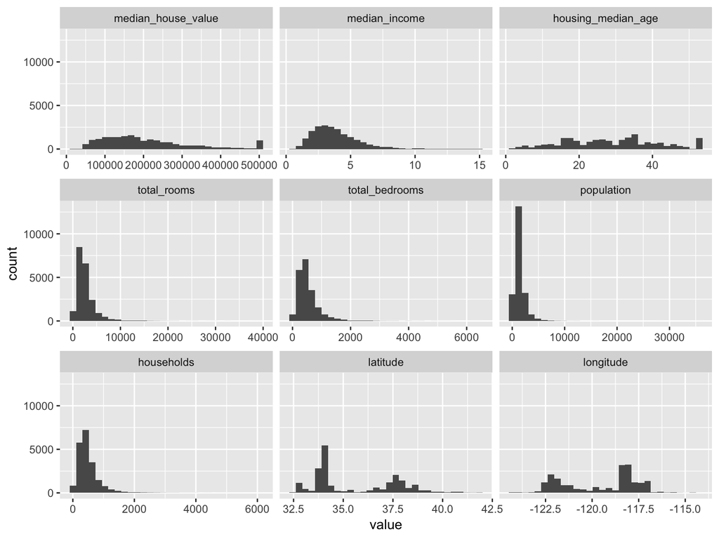

```r
ggplot(data = melt(data), mapping = aes(x = value)) +
    geom_histogram(bins = 30) + facet_wrap(~variable, scales = 'free_x')
```

In general the distribution of the data seems to make sense and there is nothing unusual. There are indeed some outliers. However, these are probably not due to bad data but can possible be explained by the difference in size between the different blocks of the California census, with the majority concentrating on similar values and a few that are larger than the rest.

### 2.2.1 Correlation between variables

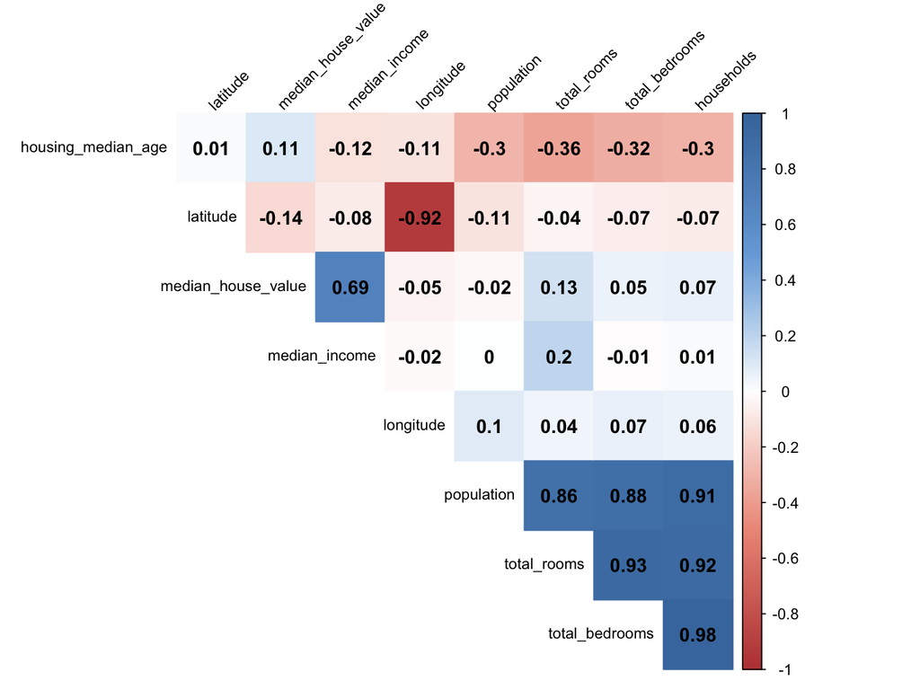

```r
col <- colorRampPalette(c("#BB4444", "#EE9988", "#FFFFFF", "#77AADD", "#4477AA"))
corrplot(cor(data), method="color", col=col(200),
         type="upper", order="hclust",
         addCoef.col = "black",
         tl.col="black", tl.srt = 45, tl.cex = 0.8,
         sig.level = 0.01, insig = "blank",
         diag=FALSE
         )
```

The target variable median_house_value has a high correlation with the variable median_income, which makes sense, so this is probably the variable with the most weight in the models.

Among the variable total_rooms, total_bedrooms, population and households there is also a high correlation, which could cause a multicollinearity problem, so these variables will be transformed in the next step.

## 2.3 Data Cleaning and Preprocessing

### 2.3.1 Feature Engineering

Given the above mentioned model we create some new variables, and drop the variables that we will not need for the model.

$$median\_income^2, \\ median\_income^3, \\
ln(median\_house\_value), \\ ln(median\_age), \\ ln(households), \\
ln(total\_bedrooms / population), \\ ln(population / households), \\ ln(total\_room / population)$$

```r
# create model variables
data_model = data %>%
  mutate(
    ln_median_house_value = log(median_house_value),
    ln_median_age = log(housing_median_age),
    ln_households = log(households),
    median_income_2 = median_income^2,
    median_income_3 = median_income^3,
    ln_trooms_popul = log(total_rooms/population),
    ln_tbedrooms_popul= log(total_bedrooms/population),
    ln_popul_households = log(population/households)
  ) %>%
  # drop unecessary variables
  select(-c(median_house_value,
            housing_median_age,
            total_rooms,
            total_bedrooms,
            population,
            households,
            latitude,
            longitude))

head(data_model)
```

```
  median_income ln_median_house_value ln_median_age ln_households
1        8.3252              13.02276      3.713572      4.836282
2        8.3014              12.78968      3.044522      7.037028
3        7.2574              12.77167      3.951244      5.176150
4        5.6431              12.74052      3.951244      5.389072
5        3.8462              12.74315      3.951244      5.556828
6        4.0368              12.50507      3.951244      5.262690
  median_income_2 median_income_3 ln_trooms_popul ln_tbedrooms_popul
1        69.30896       577.01091       1.0053704         -0.9147391
2        68.91324       572.07639       1.0840686         -0.7751354
3        52.66985       382.24620       1.0843989         -0.9595519
4        31.84458       179.70214       0.8255579         -0.8647734
5        14.79325        56.89782       1.0576674         -0.7020361
6        16.29575        65.78270       0.7998385         -0.6621554
  ln_popul_households
1           0.9382696
2           0.7466130
3           1.0304262
4           0.9352872
5           0.7799977
6           0.7607574
```

```r
# define model function
n = names(data_model)
f = as.formula(paste("ln_median_house_value ~", paste(n[!n %in% "ln_median_house_value"], collapse = " + ")))
```

### 2.3.2 Scale the independent variables

It is good practice to normalize the data before training a neural network. We will use the min-max method and scale the independent variables to the interval [0,1].

```r
data_x =  data_model[, names(data_model) != 'ln_median_house_value']

maxs = apply(data_x, 2, max)
mins = apply(data_x, 2, min)
scaled_data_x <- as.data.frame(scale(data_x, center = mins, scale = maxs - mins))

scaled_data = cbind(scaled_data_x, ln_median_house_value = data_model$ln_median_house_value)
head(scaled_data)
```

```
  median_income ln_median_age ln_households median_income_2
1     0.5396684     0.9398489     0.5550594      0.30726631
2     0.5380271     0.7705226     0.8076387      0.30550565
3     0.4660281     1.0000000     0.5940660      0.23323351
4     0.3546986     1.0000000     0.6185030      0.14057505
5     0.2307761     1.0000000     0.6377564      0.06470814
6     0.2439208     1.0000000     0.6039982      0.07139325
  median_income_3 ln_trooms_popul ln_tbedrooms_popul ln_popul_households
1      0.17093209       0.6989259          0.6418343           0.1742888
2      0.16946998       0.7068082          0.6558497           0.1487117
3      0.11322305       0.7068412          0.6373353           0.1865874
4      0.05320897       0.6809163          0.6468505           0.1738908
5      0.01682188       0.7041639          0.6631884           0.1531670
6      0.01945449       0.6783403          0.6671922           0.1505993
  ln_median_house_value
1              13.02276
2              12.78968
3              12.77167
4              12.74052
5              12.74315
6              12.50507
```

### 2.3.3 Create training and test set

We proceed by randomly splitting the data into a training and a test set.

```r
index <- sample(1:nrow(scaled_data), round(0.70*nrow(scaled_data)))
train <- scaled_data[index,]
test <- scaled_data[-index,]
```

Because the dataset is quite big and due to limited processing power we will work with a smaller sample of the training set.

```r
train.s = sample_n(train, size = 2000, replace = F)
```

### 2.3.4 Evaluation strategy

Given that we want to fit a model that makes predictions, one way of evaluating it is by calculating the MSE (mean square error), which is the average squared difference between the predicted values and the actual ones. Hence, MSE is a measure of how far our predictions are away from the true data.

# 3 Multilinear Regression

To begin with we fit a linear regression model as our base model, later we want to compare the performance of the nueral net model to the linear model.

```r
lm.fit = glm(f, data = train.s)
pred.lm = predict(lm.fit, test)

MSE.lm = sum((pred.lm - test$ln_median_house_value)^2)/nrow(test)
MSE.lm
```

```
[1] 0.1255076
```

The MSE of the linear model is 0.1255076. We should note that although we are not working with normalized predictions, the model works with the logaritmic value of the dependent variables.

# 4 Fitting the Neural Net Model

```r
nn1 = neuralnet(formula = f,
                data = train.s,
                hidden = c(2,2),
                linear.output = TRUE,
                threshold = 0.1
                )
```

In order for the model to converge the defoult threshold value had to be raised from 0.01 to 0.1, now we can visualize the net.

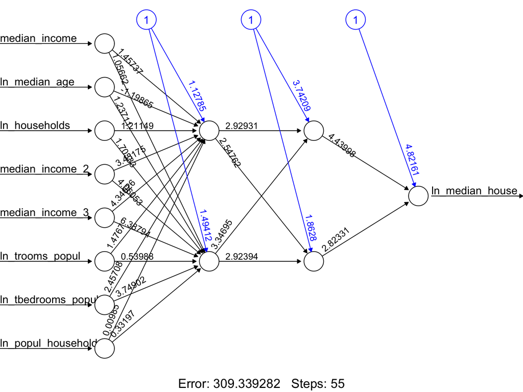

```r
plot(nn1, rep = "best")
```

The black lines show the connections between each layer and the weights on each connection while the blue lines show the bias term added in each step. The bias can be thought as the intercept of a linear model. The net is essentially a black box so we cannot say that much about the fitting, the weights and the model. Suffice to say that the training algorithm has converged and therefore the model is ready to be used.

Next, we check the model’s performance on the test data and calculate the MSE.

```r
pred.nn1 = compute(nn1, test)
MSE.nn1 = sum((pred.nn1$net.result - test$ln_median_house_value)^2)/nrow(test)
MSE.nn1
```

```
[1] 0.3196571
```

## 4.1 Structural optimization of the Neural Net

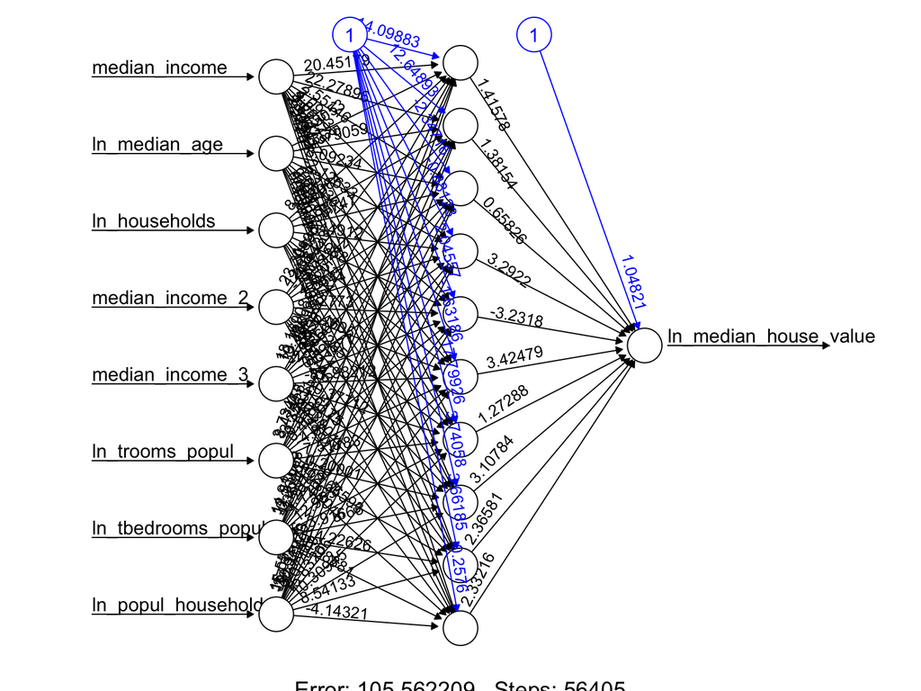

```r
nn2 = neuralnet(formula = f,
                data = train.s,
                hidden = 10,
                linear.output = TRUE,
                threshold = 0.1
                )
plot(nn2, rep = "best")
```

```r
pred.nn2 = compute(nn2, test)
MSE.nn2 = sum((pred.nn2$net.result - test$ln_median_house_value)^2)/nrow(test)
MSE.nn2
```

```
[1] 0.1135906
```

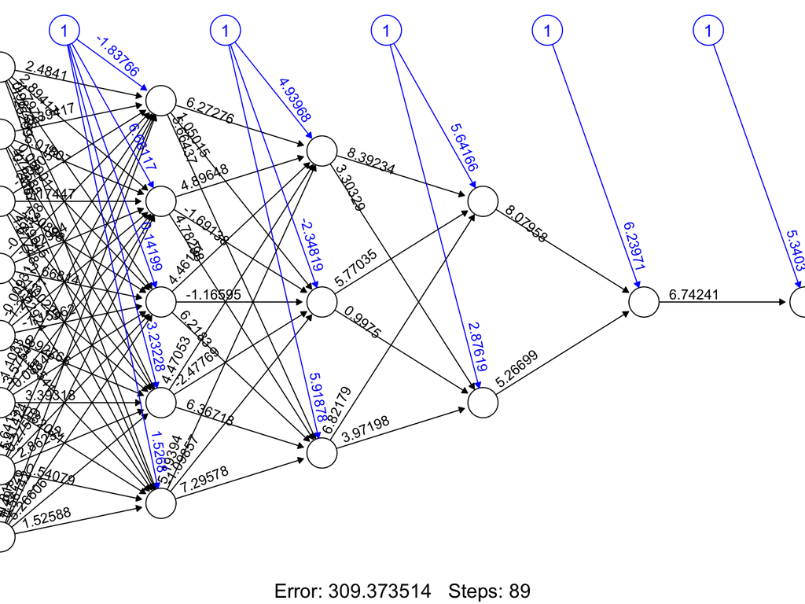

```r
nn3 = neuralnet(formula = f,
                data = train.s,
                hidden = c(5,3,2,1),
                linear.output = TRUE,
                threshold = 0.1
                )
plot(nn3, rep = "best")
```

```r
pred.nn3 = compute(nn3, test)
MSE.nn3 = sum((pred.nn3$net.result - test$ln_median_house_value)^2)/nrow(test)
MSE.nn3
```

```
[1] 0.3196922
```

The model converged a lot faster. However, it´s performance is a lot worse.

## 4.2 Parameter optimization

Given the above outcomes we will stick with our first model for now and see what happens if we alter the activation function from the default logistic to a tangent hyperbolic.

```r
nn4 = neuralnet(formula = f,
                data = train.s,
                hidden = c(2,2),
                linear.output = TRUE,
                threshold = 0.1,
                act.fct = 'tanh'
                )

pred.nn4 = compute(nn4, test)
MSE.nn4 = sum((pred.nn4$net.result - test$ln_median_house_value)^2)/nrow(test)
MSE.nn4
```

```
[1] 0.3196925
```

Well, this did not work out so well as the prediction again is much worse.

Let’s now see what happens if we increase the number of epochs.

```r
nn5 = neuralnet(formula = f,
                data = train.s,
                hidden = c(2,2),
                linear.output = TRUE,
                threshold = 0.1,
                rep = 5
                )

pred.nn5 = compute(nn4, test)
MSE.nn5 = sum((pred.nn4$net.result - test$ln_median_house_value)^2)/nrow(test)
MSE.nn5
```

```
[1] 0.3196925
```

Again, we did not achieve a better performance.

## 4.3 Evaluation

To sum up we going to visualize in a table the MSE results obtained by the different models so far.

```r
data.frame(MODEL =c("LM", "NN1", "NN2", "NN3", "NN4", "NN5"),
           MSE = c(MSE.lm, MSE.nn1, MSE.nn2, MSE.nn3, MSE.nn4, MSE.nn5)
)
```

```
  MODEL       MSE
1    LM 0.1255076
2   NN1 0.3196571
3   NN2 0.1135906
4   NN3 0.3196922
5   NN4 0.3196925
6   NN5 0.3196925
```

However, we should be careful because these results depend on the train-test split performed above. Next we are going to perform a cross validation in order to be more confident about the results.

# 5 Cross Validation

First we will cross validate the linear model and get the average MSE.

```r
library(boot)
set.seed(2019)
lm.fit <- glm(f, data = scaled_data)
cv.glm(scaled_data, lm.fit, K = 10)$delta[1]
```

```
[1] 0.1272338
```

Now the same for the Neural Net.

```r
set.seed(2019)
cv.MSE = NULL
k = 10
folds = sample(1:k, nrow(scaled_data), replace = T)

for(i in 1:k){
    # generate folds
    train.cv = scaled_data[folds != i,]
    test.cv = scaled_data[folds == i,]
    # generate subset from train.cv
    train.cv.s = sample_n(train.cv, size = 2000, replace = F)
    # fit NN model
    nn = neuralnet(f, data = train.cv.s,
                    hidden = c(2,2),
                    linear.output = T,
                    threshold = 0.1)
    # compute predictions with the model
    pr.nn = compute(nn, test.cv)
    cv.MSE[i] = sum((pr.nn$net.result - test.cv$ln_median_house_value)^2)/nrow(test.cv)
}
cv.MSE
```

```
 [1] 0.1076364 0.1204077 0.1232728 0.1182826 0.3194778 0.1273850 0.1295577
 [8] 0.1146065 0.1286406 0.3300308
```

We need to calculate the average MSE to compere it to the one of the linear model.

```r
mean(cv.MSE)
```

```
[1] 0.1619298
```

It seems that the average error is higher with the Neural Net model than with the Linear Model. We will draw a boxplot to get a clearer picture.

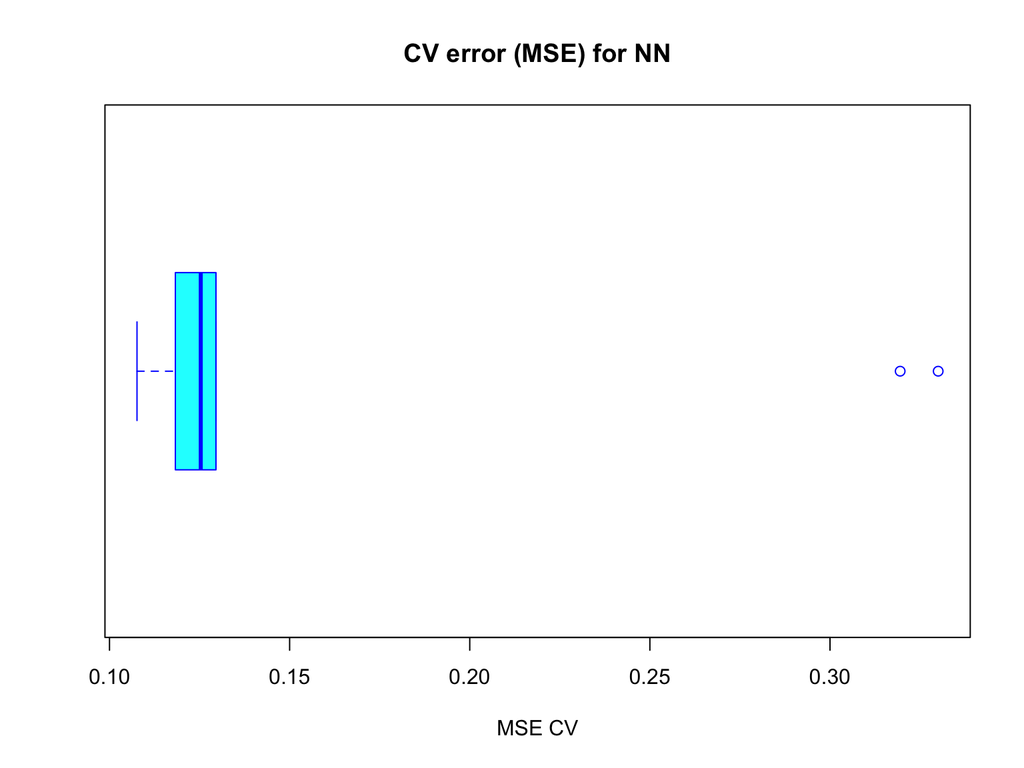

```r
boxplot(cv.MSE,xlab='MSE CV',col='cyan',
        border='blue',names='CV error (MSE)',
        main='CV error (MSE) for NN',horizontal=TRUE)
```

We can clearly see that there are two ouliers with respect to the MSE of the Neural Net model. Which means there were two splits in the dataset where the model performed quite bad.

# 6 Conclusion

In the end, after cross-validating our outcomes, the model that seems to have the best performance is the linear model. However, a few notes on this outcome.

We should consider that there is no blueprint to fitting a neural network and as we have seen, small changes can lead to quite different results. Maybe a different setting could still lead to better results than the liner model.

Also, we only used a small subset of the data in order to train the model due to limited processing power, training on a bigger sample again could improve the outcome.

On the other hand, one drawback of the neural network is that it remains a black box and it is hard to gain any insight from the model, whereas with a linear model it is easy to get a insight and explain the outcome. Thus, in case that we would be interested in the relative importance of the different variables regarding our target variable than the linear model would be the prefered model to use.